# How To Work With Multiple Github Accounts on a single Machine

https://gist.github.com/rahularity/86da20fe3858e6b311de068201d279e3

Let suppose I have two github accounts, https://github.com/seifriz and https://github.com/fs1967. Now I want to setup my computer (Dell-3640) to easily talk to both the github accounts.

> NOTE: This logic can be extended to more than two accounts also. :)

The setup can be done in 5 easy steps:

- Step1 : Create SSH keys for all accounts
- Step 2 : Add SSH keys to SSH Agent
- Step 3 : Add SSH public key to the Github
- Step 4 : Create a Config File and Make Host Entries
- Step 5 : Cloning GitHub repositories using different accounts

## Step 1

### Create SSH keys for all accounts

First make sure your current directory is your **.ssh** folder. Open the Git-Bash:

```bash
     $ cd ~/.ssh
```

Syntax for generating unique ssh key for an account is:

```bash
     ssh-keygen -t rsa -C "your-email-address" -f "github-username"
```

here,

**-C** stands for comment to help identify your ssh key

**-f** stands for the file name where your ssh key get saved

#### Now generating SSH keys for my two accounts

```bash
     ssh-keygen -t rsa -C "seifriz@dshs-koeln.de" -f "github-seifriz"
     ssh-keygen -t rsa -C "f.seifriz@flosoft.de" -f "github-fs1967"
```

Notice here **seifriz** and **fs1967** are the username of my github accounts corresponding to **seifriz@dshs-koeln.de** and **f.seifriz@flosoft.de** email ids respectively.

After entering the command the terminal will ask for passphrase, leave it empty and proceed.

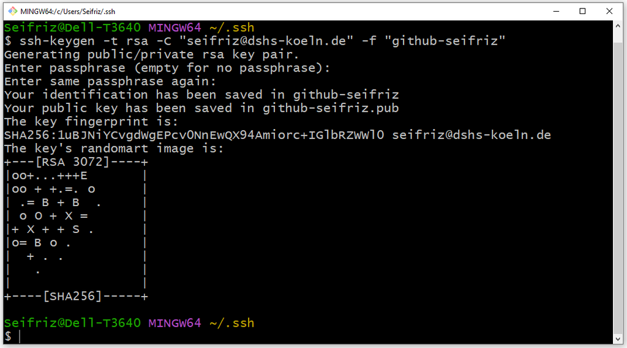

Passphrase Image

Now after adding keys, in your .ssh folder, a public key (*.pub) and a private will get generated. The public key will have an extension (*.pub) and private key will be there without any extension both having same name which you have passed after **-f** option in the above command. (in my case **github-seifriz** and **github-fs1967**)

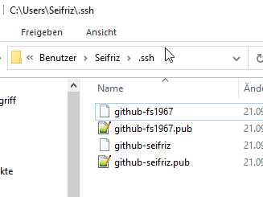

Added Key Image

## Step 2

### Add SSH keys to SSH Agent

If the SSH Agent is not started

```bash
     eval $(ssh-agent -s)
```

Now we have the keys but it cannot be used until we add them to the SSH Agent.

```bash
     ssh-add ~/.ssh/github-seifriz
     ssh-add ~/.ssh/github-fs1967
```

You can read more about adding keys to SSH Agent [here.](https://help.github.com/en/github/authenticating-to-github/generating-a-new-ssh-key-and-adding-it-to-the-ssh-agent)

## Step 3

### Add SSH public key to the Github

For the next step we need to add our public key (that we have generated in our previous step; *.pub) and add it to corresponding github accounts.

For doing this we need to paste the public key (*.pub) on Github:

- Sign in to Github each account
- Goto Settings > SSH and GPG keys > New SSH Key
- Paste your copied public key (*.pub) and give it a title of your choice.
- Example: “**fs1967@Dell-3640**” and “**seifriz@Dell-3640**”

## Step 4

### Create a Config File and Make Host Entries

The **~/.ssh/config** file allows us specify many config options for SSH.

If **config** file not already exists then create one (make sure you are in **~/.ssh** directory)

Now we need to add these lines to the file, each block corresponding to each account we created earlier.

```
     # seifriz@dshs-koeln.de - GitHub account: seifriz
     Host github.com-seifriz
          HostName github.com
          User git
          IdentityFile ~/.ssh/github-seifriz

     # f.seifriz@flosoft.de - GitHub account: fs1967
     Host github.com-fs1967
          HostName github.com
          User git
          IdentityFile ~/.ssh/github-fs1967
```

## Step 5

### Cloning GitHub repositories using different accounts

So we are done with our setups and now its time to see it in action. We will clone a repository using one of the account we have added.

Make a new project folder where you want to clone your repository and go to that directory from your terminal.

```
 git clone git@github.com-fs1967:fs1967/TestRepo.git
 git clone git@github.com-seifriz:seifriz/TestRepo.git
```

## Finally

From now on, to ensure that our commits and pushes from each repository on the system uses the correct GitHub user we will have to configure **user.email** and **user.name** in every repository freshly cloned or existing before.

Therefore edit the **.git/config** file in each repository or do this use the following commands.

```
     git config user.email "seifriz@dshs.de"
     git config user.name "seifriz"

     git config user.email "f.seifriz@flosoft.de"
     git config user.name "fs1967"
```

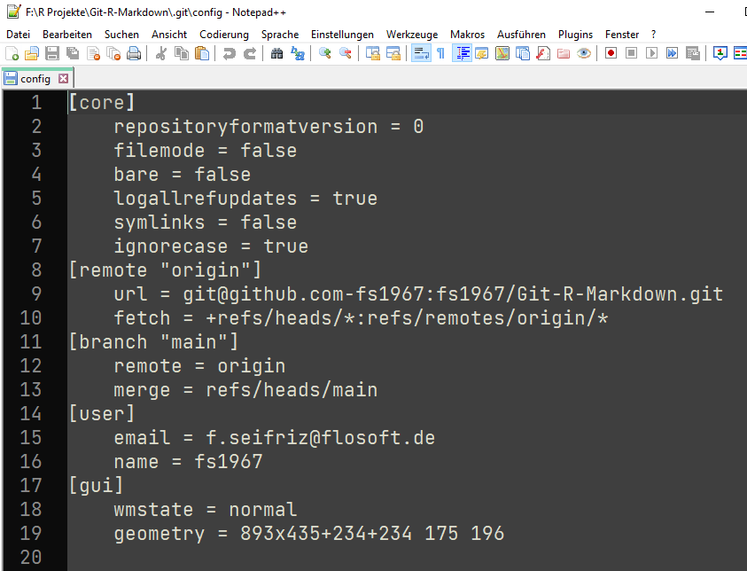

config file in .git folder

## Using Git Bash

To push or pull to the correct account we need to add the remote origin to the project

```
     git remote add origin git@github.com-seifriz:seifriz

     git remote add origin git@github.com-fs1967:fs1967
```

Now you can use:

```
     git push

     git pull
```

## Using Git GUI

1. Stage
2. Commit
3. Push